# APM1110 FA6: Probability and Probability Distributions

Angelina Jolie C. Peña

2026-09-16

# SECTION I. GEOMETRIC DISTRIBUTION

## Provide an R code for the geometric distribution. The geometric distribution is a probability distribution that models the number of trials required to achieve the first success in a sequence of Bernoulli trials, where each trial has a constant probability of success.

## 1. Set the probability of success

```r
p <- 0.2
```

## 2. Generate 1000 random variables from the geometric distribution

## R’s rgeom() gives the number of failures BEFORE the first success. Therefore, +1 is added to obtain the number of trials required to achieve the first success.

```r
x <- rgeom(1000, p) + 1
```

## 3. Calculate the basic statistics

```r
mean_x <- mean(x)
var_x <- var(x)
sd_x <- sd(x)
```

## 4. Print the results using the required output format

```r
cat("Number of trials required to achieve first success:",
    length(x), "\n")
```

```
## Number of trials required to achieve first success: 1000
```

```r
cat("Mean (in 2 decimal places):",
    sprintf("%.2f", mean_x), "\n")
```

```
## Mean (in 2 decimal places): 5.17
```

```r
cat("Variance (in 2 decimal places):",
    sprintf("%.2f", var_x), "\n")
```

```
## Variance (in 2 decimal places): 20.05
```

```r
cat("Standard deviation (in 2 decimal places):",
    sprintf("%.2f", sd_x), "\n")
```

```
## Standard deviation (in 2 decimal places): 4.48
```

## 5. Plot the histogram of the results

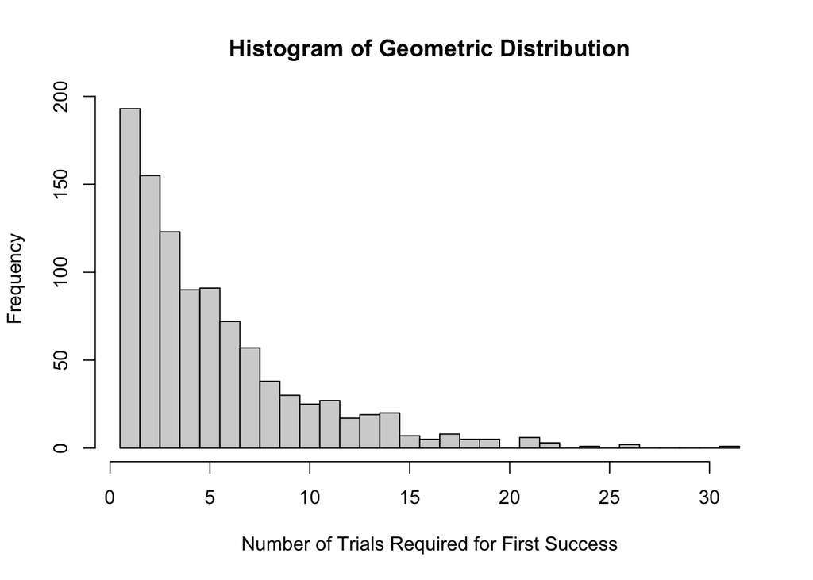

```r
hist(x,
     breaks = seq(min(x) - 0.5, max(x) + 0.5, by = 1),
     main = "Histogram of Geometric Distribution",
     xlab = "Number of Trials Required for First Success",
     ylab = "Frequency",
     col = "lightgray",
     border = "black")
```

# SECTION II. HYPERGEOMETRIC DISTRIBUTION

## Consider a plant manufacturing IC chips of which 10% are expected to be defective. The chips are packed in boxes for export. Before transportation, a sample is drawn from each box. Estimate the probability that the sample contains more than 10% defectives, when:

## 1. A sample of 10 is selected from a box of 40;

## 2. A sample of 10 is selected from a box of 5000.

## Given:

## 10% of the IC chips are expected to be defective

```r
p_defective <- 0.10
```

## A sample of 10 is selected

```r
n <- 10
```

## II.1 A sample of 10 is selected from a box of 40

```r
N1 <- 40                         # Population size
M1 <- N1 * p_defective           # Number of defective chips
L1 <- N1 - M1                    # Number of non-defective chips

# More than 10% of 10 chips means MORE THAN 1 defective chip.
# Therefore, we need P(X > 1), or equivalently P(X >= 2).

prob_more_than_10_1 <- 1 - phyper(1, M1, L1, n)

cat("\nProbability for N = 40:\n")
```

```
##
## Probability for N = 40:
```

```r
cat("P(X > 1) =", sprintf("%.4f", prob_more_than_10_1), "\n")
```

```
## P(X > 1) = 0.2559
```

```r
cat("Percentage =", sprintf("%.2f%%", prob_more_than_10_1 * 100), "\n")
```

```
## Percentage = 25.59%
```

## INTERPRETATION: The probability that a sample of 10 chips contains more than 10% defective chips is approximately 25.59%. This means there is about a 25.59% chance that the sample will contain at least 2 defective chips.

## II.2 A sample of 10 is selected from a box of 5000

```r
N2 <- 5000                       # Population size
M2 <- N2 * p_defective           # Number of defective chips
L2 <- N2 - M2                    # Number of non-defective chips

# Again, more than 10% of 10 chips means MORE THAN 1
# defective chip.
# Therefore, we calculate P(X > 1) = 1 - P(X <= 1).

prob_more_than_10_2 <- 1 - phyper(1, M2, L2, n)

cat("\nProbability for N = 5000:\n")
```

```
##
## Probability for N = 5000:
```

```r
cat("P(X > 1) =", sprintf("%.4f", prob_more_than_10_2), "\n")
```

```
## P(X > 1) = 0.2639
```

```r
cat("Percentage =", sprintf("%.2f%%", prob_more_than_10_2 * 100), "\n")
```

```
## Percentage = 26.39%
```

## INTERPRETATION: The probability that a sample of 10 chips contains more than 10% defective chips is approximately 26.39%. This means there is about a 26.39% chance that the sample will contain at least 2 defective chips.